# Projet : Super Market Sales Visualizations

## La relation entre les produits et les quantités:

# Plot the boxplot of Total purchase amount by Product line

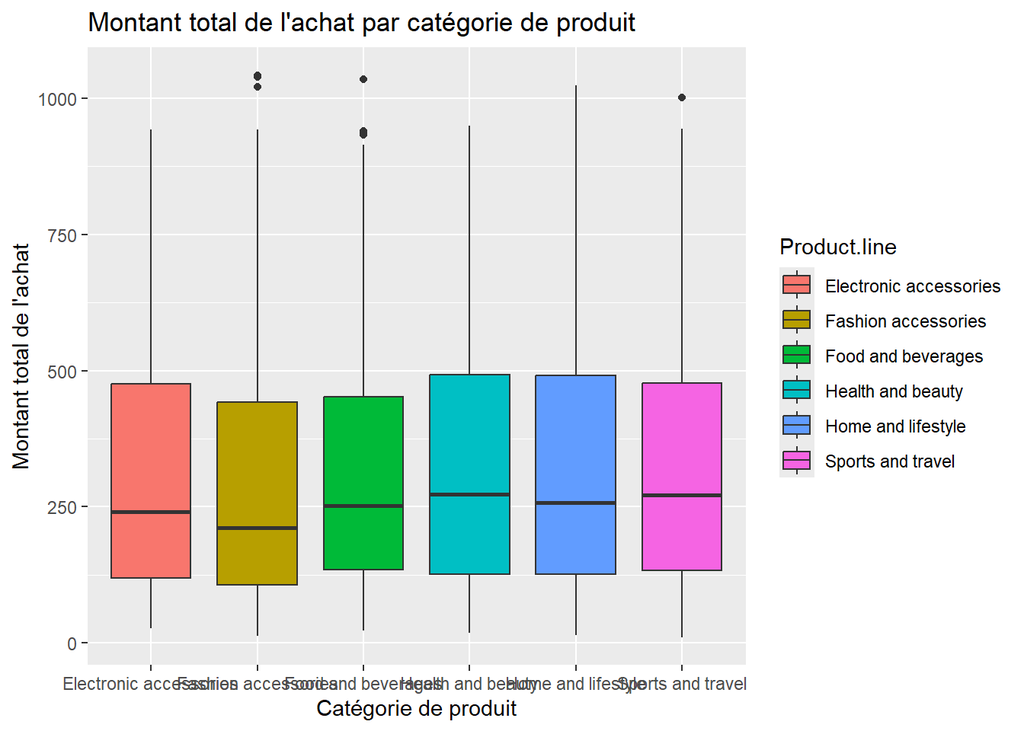

```r
ggplot(basesm, aes(x = Product.line, y = Total, fill = Product.line)) +
  geom_boxplot() +
  labs(title = "Montant total de l'achat par catégorie de produit",
       x = "Catégorie de produit",
       y = "Montant total de l'achat")
```

# Plot the histogram of Quantity

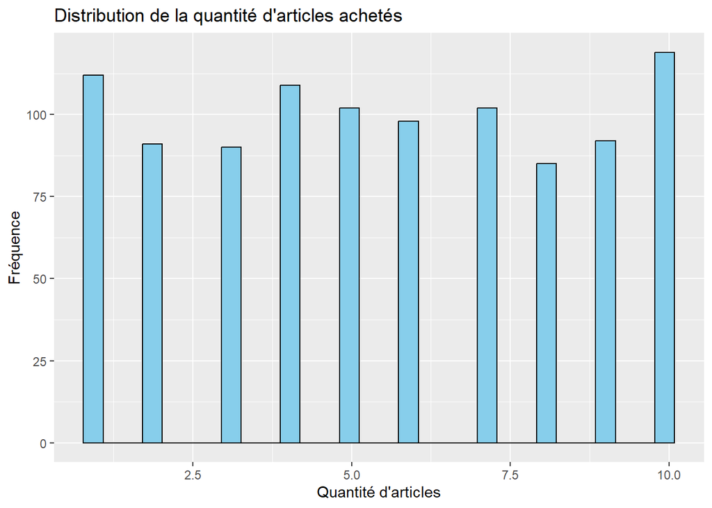

```r
ggplot(basesm, aes(x = Quantity)) +
  geom_histogram(fill = "skyblue", color = "black", bins = 30) +
  labs(title = "Distribution de la quantité d'articles achetés",
       x = "Quantité d'articles",
       y = "Fréquence")
```

=> Cet histogramme illustre la distribution de la quantité d’articles achetés dans le supermarché. La fréquence des quantité d’articles égale à 10 est la plus supérieur pendant que la la quantité d’article égale à 8 a la plus faible frequence.

# Plot the histogram of Gross income

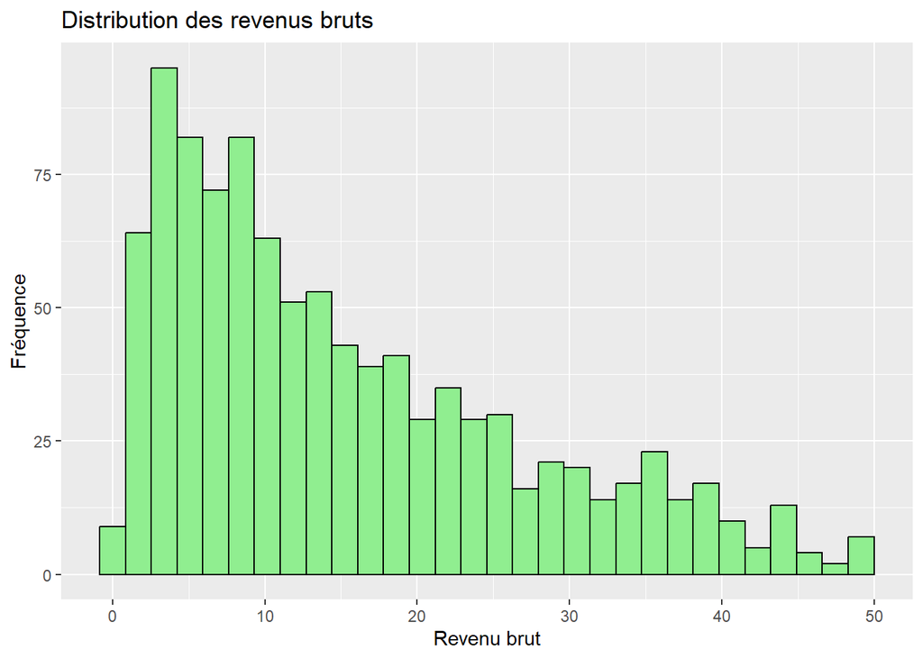

```r
ggplot(basesm, aes(x = gross.income)) +
  geom_histogram(fill = "lightgreen", color = "black", bins = 30) +
  labs(title = "Distribution des revenus bruts",
       x = "Revenu brut",
       y = "Fréquence")
```

=> Cet histogramme présente la distribution des revenus bruts générés par les ventes de produits dans le supermarché. Plus le revenue brute croit plus la frequence decroit .

## Les produits et leurs évaluations:

# Plot the histogram of Rating

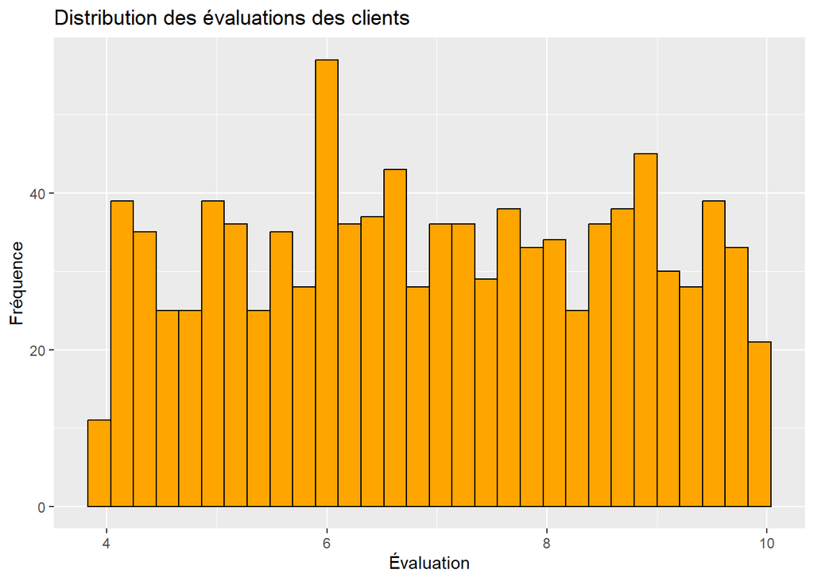

```r
ggplot(basesm, aes(x = Rating)) +
  geom_histogram(fill = "orange", color = "black", bins = 30) +
  labs(title = "Distribution des évaluations des clients",
       x = "Évaluation",
       y = "Fréquence")
```

=> Cet histogramme illustre la distribution des évaluations données par les clients pour leur expérience d’achat dans le supermarché. la note la plus donnée est égale a 6 . c’est un peut rare pour un client qu’il donne la note 4 ou 10.

# La dispersion entre le mode de paiement et la notation.

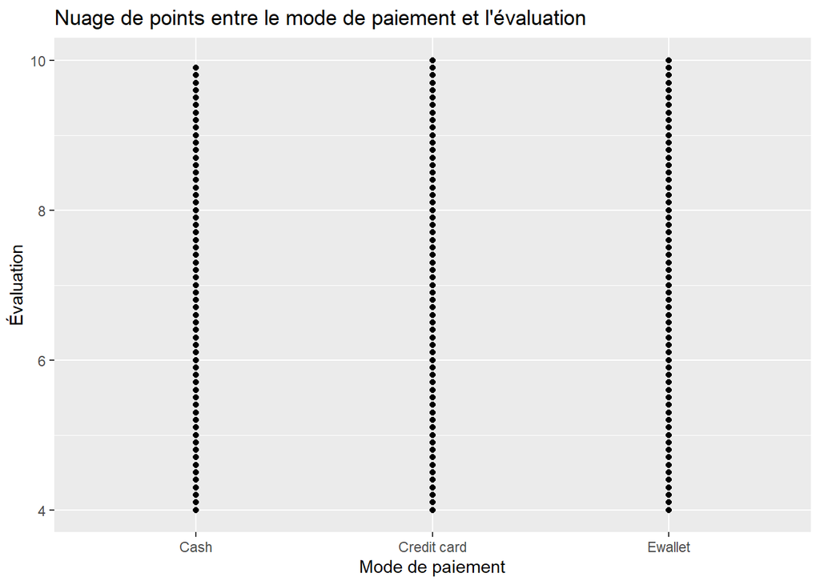

```r
ggplot(basesm) +
  geom_point(aes(x = Payment, y = Rating)) +
  labs(title = "Nuage de points entre le mode de paiement et l'évaluation",
       x = "Mode de paiement",
       y = "Évaluation")
```

## Les types de produits et leurs ventes:

# La distribution des lignes de produits

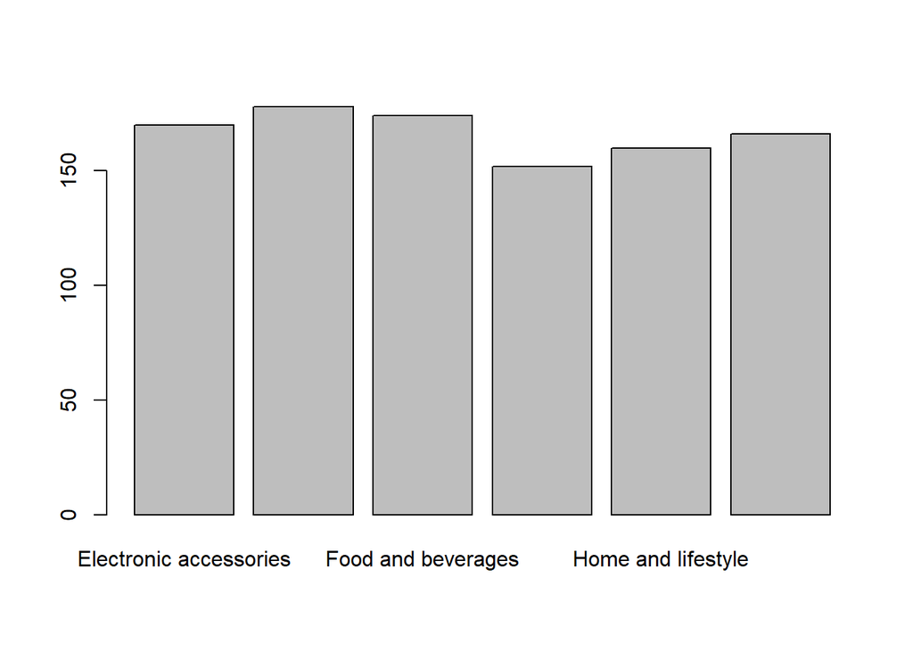

```r
barplot(table(basesm$Product.line))
```

=> Ce barplot présente la répartition des différents types de produits vendus dans le supermarché.L’existance des produits du Fashion Accesoiries est la plus remarquable pendant qu’il n ya pas trop de produit de Health and Beauty.